# SI 618 - Homework #2: More Data Manipulation

### The total score for this assignment will be 100 points, consisting of:

- 10 pt: Overall quality of spelling, grammar, punctuation, etc. of written sentences. ([Guide](https://drive.google.com/file/d/1L0P7xJwjUGBvyb49mL3dw1Bt7hzRTiTl/view))
- 10 pt: Codes are written in [PEP 8](https://www.python.org/dev/peps/pep-0008/) style.
- 80 pt: Homework questions.

# Background

You're a Data Science Consultant for an eCommerce retail company, they've asked you to analyze their sales database. Unfortunately, they did nothing to prepare or clean their data, only exporting their 3 database tables as JSON files. It's up to you to clean their data, analyze it and answer questions to help drive business value!

### The below files have been provided:

- invoices.json
- items.json
- purchases.json

### They provided this data dictionary:

**InvoiceNo:** Invoice number. Nominal, a 6-digit integral number uniquely assigned to each transaction.  
**StockCode:** Product (item) code. Nominal, a 5-digit integral number uniquely assigned to each distinct product.  
**Description:** Product (item) name. Nominal.  
**Quantity:** The quantities of each product (item) per transaction. Numeric.  
**InvoiceDate:** Invoice Date and time. Numeric, the day and time when each transaction was generated.  
**UnitPrice:** Unit price. Numeric, Product price per unit in sterling.  
**CustomerID:** Customer number. Nominal, a 5-digit integral number uniquely assigned to each customer.  
**Country:** Country name. Nominal, the name of the country where each customer resides.

### A few notes from the company:

- If the InvoiceNo starts with the letter 'c', it indicates a cancellation. When conducting this analysis we only want to analyze invoices that were shipped. (ie. not canceled)
- The datasets should be able to be merged, each row in the invoice table corresponds to multiple rows in the purchases table.
- To find out the description or unit cost of an item in the purchase table, the StockCode should be used to match up the product in the items table.
- They mentioned that they've been having a difficult time lately joining the items and purchases table, maybe there's something wrong with the columns?

# Answer the questions below.

- Write your Python code that can answer the following questions,
- and explain **ALL** your answers in plain English.

```python
MY_UNIQNAME = 'drewpap'
```

### Q1. [5 points] Describe the dataset.

1. Load the data.
2. How many total invoices have been placed?
3. How many unique customers are there?
4. What the total number of unique items?
5. Are there any columns with null values?
6. Thinking ahead, how do you think you would join the different tables? Please share 2-3 sentences about your approach.

```python
import pandas as pd
import numpy as np


# Import all json files
invoices_data = pd.read_json("invoices.json")
items_data = pd.read_json("items.json")
purchases_data = pd.read_json("purchases.json")

def checkMissingVals(a_dataframe):
    '''Checks the data frame for missing values in each column and prints
        out whether or not there are null values

        Parameters
        ----------
        a_dataframe : DataFrame
            A data frame to check
        Returns
        -------
        None
    '''

    for column in a_dataframe:
        if a_dataframe[column].isnull().values.any():
            print(f"{column} column has missing values")
        else:
            print(f"{column} column does not have missing values")
    print("\n")


##### INVOICE PROCESSING CODE #####

#Check if any of the InvoiceNo column begins with a lowercase c to replace if true
invoices_data[invoices_data["InvoiceNo"].str.startswith("c") == True]

# Check for uppercase C in invoices to filter out all cancellations
invoices_no_cancellations = invoices_data[invoices_data["InvoiceNo"].str.startswith("C") == False]
invoices_no_cancellations = invoices_no_cancellations.drop_duplicates() # Check for duplicated entries

print(f"Total number of invoices placed: {len(invoices_no_cancellations['InvoiceNo'])}")

# Columns with null values
print("\nInvoices data missing values: \n")
checkMissingVals(invoices_no_cancellations)

# Find unique number of customers

print(f"Number of unique customers: {len(invoices_no_cancellations['CustomerID'].unique())}")

##### END INVOICE CODE #####


##### ITEMS DATA CODE #####

# Look for missing valuses
print("\nItems data missing values: \n")
checkMissingVals(items_data)

# Find unique number of items
print(f"Number of unique items: {len(items_data['StockCode'].unique())}")

##### END ITEMS DATA CODE #####


##### PURCHASES DATA CODE #####

# Change incorrect StockCodeSC to StockCode for merging
purchases_data.rename(columns = {"StockCodeSC":"StockCode"}, inplace = True)

# Use replace to match "SC" in the string for each column and replace the found characters with an empty string
purchases_data["StockCode"] = purchases_data["StockCode"].str.replace(pat = "SC", repl = "")

# Remove any invoices that were cancelled
purchases_data_no_cancellations = purchases_data[purchases_data["InvoiceNo"].str.startswith("C") == False]
purchases_data_no_cancellations

#Check for null values
print("\nPurchases data missing values: \n")
checkMissingVals(purchases_data_no_cancellations)

##### END PURCHASES DATA CODE #####


# invoices_no_cancellations
# items_data
# purchases_data_no_cancellations
```

```
Total number of invoices placed: 22106

Invoices data missing values:

InvoiceNo column does not have missing values
InvoiceDate column does not have missing values
CustomerID column has missing values
Country column does not have missing values


Number of unique customers: 4340

Items data missing values:

StockCode column does not have missing values
Description column has missing values
UnitPrice column does not have missing values


Number of unique items: 4070

Purchases data missing values:

InvoiceNo column does not have missing values
StockCode column does not have missing values
Quantity column does not have missing values
```

1.2: To determine the total number of invoices placed, I removed any cancelled invoices by filtering on InvoiceNo entries that began with C. I then looked at the length of the InvoiceNo column of the filtered data frame. I cross checked this number with the number of unique InvoiceNo entries and found that they do not match. I assume this is because of some sort of invoice number duplication. However, I believe we ought to be liberal in our count and include potential duplications under the assumption that there was an algorithmic error in creating the entry and that those purchases did indeed go through. That said, the total number of invoices placed was 22,106.

1.3: To determine the number of unique customers I used the invoices data frame with all cancelled orders removed. I found all unique customers by looking at all of the unique customer IDs in the data frame and finding the length of that list. There were a total of 4340 unique customers.

1.4: After checking whether there are missing values in the StockCode column of the items_data data frame and determining that there are no missing values, I found the length of the number of unique stock codes. Each stock code correlates with a unique item, so finding the length of the stock codes column tells us how many unique items there are. There are a total of 4070 unique items.

1.5: There are columns with null values in two of the data frames. To find null values, I created a function that checks each column for null values and prints out whether or not that column has missing values. From the output above, we see that there are missing values in the invoices data and the items data. There there are null customer IDs in the invoices data and there are null descriptions in the items data.

1.6: In order to join the data, I plan on merging the purchases and item data together on stock code. There was a problem with the purchases data in that the StockCodeSC column was not supposed to have the additional SC. I removed the SC in the column name and removed all instances of SC in each row of the stock code column in the purchases data. That will allow me to merge purchases and items together so that each will have the associated purchase/item information together. From there, I will merge that new data frame with the invoices data frame so that each row will have an invoice number so that each invoice will be populated with information about the purchaser and the item. This will allow for easier analysis as grouping can be done on customer ID, stock code, invoice number, country, etc.

```python
#Merge the cleaned data set together going forward
purchases_and_item_data_no_cancel = purchases_data_no_cancellations.merge(items_data, on = "StockCode")
cleaned_data = purchases_and_item_data_no_cancel.merge(invoices_no_cancellations, on = "InvoiceNo")
cleaned_data
```

|  | InvoiceNo | StockCode | Quantity | Description | UnitPrice | InvoiceDate | CustomerID | Country |
| --- | --- | --- | --- | --- | --- | --- | --- | --- |
| 0 | 536365 | 85123A | 6 | WHITE HANGING HEART T-LIGHT HOLDER | 2.55 | 12/1/10 8:26 | 17850.0 | United Kingdom |
| 1 | 536365 | 71053 | 6 | WHITE METAL LANTERN | 3.39 | 12/1/10 8:26 | 17850.0 | United Kingdom |
| 2 | 536365 | 84406B | 8 | CREAM CUPID HEARTS COAT HANGER | 2.75 | 12/1/10 8:26 | 17850.0 | United Kingdom |
| 3 | 536365 | 84029G | 6 | KNITTED UNION FLAG HOT WATER BOTTLE | 3.39 | 12/1/10 8:26 | 17850.0 | United Kingdom |
| 4 | 536365 | 84029E | 6 | RED WOOLLY HOTTIE WHITE HEART. | 3.39 | 12/1/10 8:26 | 17850.0 | United Kingdom |
| ... | ... | ... | ... | ... | ... | ... | ... | ... |
| 535960 | 580542 | 23560 | 6 | SET OF 6 RIBBONS COUNTRY STYLE | 2.89 | 12/5/11 9:04 | 15358.0 | United Kingdom |
| 535961 | 580542 | 23562 | 6 | SET OF 6 RIBBONS PERFECTLY PRETTY | 2.89 | 12/5/11 9:04 | 15358.0 | United Kingdom |
| 535962 | 580542 | 23561 | 6 | SET OF 6 RIBBONS PARTY | 2.89 | 12/5/11 9:04 | 15358.0 | United Kingdom |
| 535963 | 579108 | 23561 | 24 | SET OF 6 RIBBONS PARTY | 2.89 | 11/28/11 11:44 | 16705.0 | United Kingdom |
| 535964 | 581483 | 23843 | 80995 | PAPER CRAFT , LITTLE BIRDIE | 2.08 | 12/9/11 9:15 | 16446.0 | United Kingdom |

535965 rows × 8 columns

### Q2. [10 points] Invoice Analysis

1. For each customer calculate how many total invoices they have placed. List the top 10 customers who have placed an invoice in descending order.
2. Perform a similar calculation but instead of the number of invoices, calculate the total quantity of items ordered for each customer. List the top 10 customers in descending order.
3. Compare the top 10 customers, does it appear that the more invoices a customer have, the greater the total quantity of items? Explain your reasoning.

*Hint: For 2.2, you may need to join two datasets together to answer the question.*

```python
# Top 10 customers by number of invoices
invoices_no_cancellations
invoice_per_customer_series = invoices_no_cancellations[["CustomerID", "InvoiceNo"]].groupby("CustomerID")["InvoiceNo"].count()
invoice_per_customer_frame = invoice_per_customer_series.to_frame().reset_index().rename(columns = {"InvoiceNo":"NumInvoices"})

top_eleven_invoices = invoice_per_customer_frame.sort_values("NumInvoices", ascending = False)[0:11] #List to 11 to check for ties

top_ten_invoices = top_eleven_invoices[0:10].reset_index().drop(columns = "index")
print(top_ten_invoices)

# Quantity analysis
purchases_and_invoices = purchases_data_no_cancellations.merge(invoices_no_cancellations, on = "InvoiceNo")
quantity_and_customer_id= purchases_and_invoices[["CustomerID","Quantity"]]
qty_cust_counts_series = quantity_and_customer_id.groupby("CustomerID")["Quantity"].count()
qty_cust_counts_df = qty_cust_counts_series.to_frame().reset_index().rename(columns = {"Quantity": "QtyItemsPurchased"})

top_eleven_qty_items_purchased = qty_cust_counts_df.sort_values("QtyItemsPurchased",ascending = False)[0:11] #Set 11 to check for ties
top_ten_qty = top_eleven_qty_items_purchased[0:10].reset_index().drop(columns = "index")
print("\n",top_ten_qty)


# Comparison analysis
top_ten_qty.merge(top_ten_invoices, how = 'outer')
```

```
   CustomerID  NumInvoices
0     12748.0          211
1     14911.0          202
2     17841.0          124
3     13089.0           97
4     14606.0           95
5     15311.0           91
6     12971.0           86
7     14646.0           74
8     16029.0           63
9     13408.0           62

    CustomerID  QtyItemsPurchased
0     17841.0               7847
1     14911.0               5716
2     14096.0               5111
3     12748.0               4685
4     14606.0               2758
5     15311.0               2379
6     14646.0               2080
7     13089.0               1818
8     13263.0               1677
9     14298.0               1637
```

|  | CustomerID | QtyItemsPurchased | NumInvoices |
| --- | --- | --- | --- |
| 0 | 17841.0 | 7847.0 | 124.0 |
| 1 | 14911.0 | 5716.0 | 202.0 |
| 2 | 14096.0 | 5111.0 | NaN |
| 3 | 12748.0 | 4685.0 | 211.0 |
| 4 | 14606.0 | 2758.0 | 95.0 |
| 5 | 15311.0 | 2379.0 | 91.0 |
| 6 | 14646.0 | 2080.0 | 74.0 |
| 7 | 13089.0 | 1818.0 | 97.0 |
| 8 | 13263.0 | 1677.0 | NaN |
| 9 | 14298.0 | 1637.0 | NaN |
| 10 | 12971.0 | NaN | 86.0 |
| 11 | 16029.0 | NaN | 63.0 |
| 12 | 13408.0 | NaN | 62.0 |

2.3: To compare the two lists of top 10 customers, I performed an outer merge on the two top 10 lists. I performed an outer merge so that NaN values would appear in rows where the customer was not on both lists. Six customers made one list, but not the other, indicating that their associated invoices or quantity was not sufficiently high to make the list. This says something about the relationship of invoices to item quantity. If there were a strong relationship, we would expect that those with a high number of invoices, would also have a very high quantity of items purchased as well. Additonally, if we sort on the number of invoices for each customer, there is not a clear pattern. The highest number of invoices was 211 with an associated quantity of 4685 items. However, the maximum for quantity was 7847, with only 124 invoices. There is not a clear relationship from this sample. To further test this we could perform a linear regression on a larger sample of this data to confirm this hypothesis.

### Q3. [10 points] Item Analysis

1. What is the average item-unit price?
2. What % of items are under $20?
3. Generate a histogram of the unit prices. Select reasonable min/max values for the x-axis. Why did you pick those values? What do you notice about the histogram?

```
          UnitPrice
count   3855.000000
mean       7.290397
std      178.548626
min        0.001000
25%        1.250000
50%        2.510000
75%        4.950000
max    11062.060000

98.29% of items cost less than $20

     StockCode                  Description  UnitPrice
3753         B              Adjust bad debt   11062.06
952        DOT               DOTCOM POSTAGE     569.77
1591     22655  VINTAGE RED KITCHEN CABINET     295.00
```

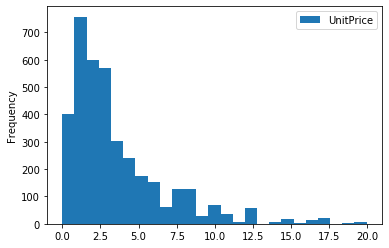

```python
# Average item-unit price

# Filter out all non-zero items
items_data_no_zeroes = items_data[items_data["UnitPrice"] != 0]
print(items_data_no_zeroes.describe())

# Items under $20
items_under_twenty = items_data_no_zeroes[items_data_no_zeroes["UnitPrice"] < 20]["UnitPrice"]
percentage_under_twenty = round(len(items_under_twenty) / len(items_data_no_zeroes["UnitPrice"]),4) * 100
print(f"\n{percentage_under_twenty}% of items cost less than $20\n")

# Histogram of unit prices
print(items_data_no_zeroes[items_data_no_zeroes["UnitPrice"] > 20].sort_values(by = "UnitPrice", ascending = False)[0:3])
print()

items_data_no_outliers = items_data_no_zeroes[(items_data_no_zeroes["UnitPrice"] <= 20) & items_data_no_zeroes["UnitPrice"] > 0.05]
items_data_no_outliers.plot.hist(bins = 25)
```

3.1: To find the average item-unit price, I used the items data frame and filtered out all items with a unit price of 0. Several of these items are marked unsellable in their descriptions and many have a description of None. As such, it makes sense to remove them from the calculation of the average item-unit price as they will unnecessarily lower the average. I used the describe() function to get a summary of the unit price column and found that the mean unit price is 7.29 and the median is 2.51. I believe the median is more representative of the average unit-price because it appears that there are outliers pullling the mean higher than it ought to be. Looking at the 75th percentile value, we see a value of 4.95. A mean of 7.29 is higher than the 75th percentile, further solidifying that it is not representative of the average of the distribution.

3.2: To find the percentage of items worth less than twenty dollars, I filtered out all of the items with a value of 0 and filtered for all items with a unit price of less than twenty. I took the length of that series and divided by the length of the series of all items with a unit price greater than 0. After dividing the two, the percentage of items that cost less than twenty dollars is 98.29%

3.3: To create a histogram of unit prices, I first looked for outliers in the items data frame with non zero prices. After filtering for items over twenty dollars, I found two large outliers at the end of the set. One, an adjustment of bad debt that is clearly not an item for 11,062 dollars and postage to the tune of 569 dollars. Additionally, I saw several discounts and adjustments when looking at values over twenty dollars. That said, I selected a maximum of twenty dollars for the histogram so that meaningful bins can be seen. I chose a minimum of 0.05 dollars to exclude the 0.001 that seems erroneous. This range (0.05 - 20) will encompass the vast majority of the data and allows the histogram to show meaningful distinction between bins. Looking at the histogram, we see that the vast majority of values are clustered around the 2.5 dollar mark. The high clustering around low values alludes to the strategy of the company. Attract customers with low prices and try to sell in high volume.

### Q4. [25 points] Order Trends

1. What are the top 10 most ordered items? Describe them, do you see any trends?
2. What are the top 5 invoices that generated the most revenue? (Revenue is calculated by marking up the unit price by 25%.)
3. Do the top invoices contain any of the top 10 most ordered items?

*Hint: When calculating the revenue we suggest adding a new column on the dataframe.*

```python
# Top 10 most ordered items
stock_code_and_qty = cleaned_data[["StockCode", "Quantity"]]

stock_code_and_qty_sum_series = stock_code_and_qty[stock_code_and_qty["Quantity"] > 0].groupby("StockCode")["Quantity"].sum()
stock_code_and_qty_sum_df = stock_code_and_qty_sum_series.to_frame().reset_index().sort_values(by = "Quantity", ascending = False)
top_ten_stock_code_qty_df = stock_code_and_qty_sum_df[0:10]



print(top_ten_stock_code_qty_df.merge(cleaned_data[["Description","StockCode"]], on = "StockCode", how = "left").drop_duplicates().set_index("StockCode"))

# Top 5 invoices with the most revenue
invoice_qty_unit_price = cleaned_data[["InvoiceNo","StockCode","Quantity","UnitPrice"]]
invoice_qty_unit_price = invoice_qty_unit_price[invoice_qty_unit_price["UnitPrice"] > 0.05]
invoice_qty_unit_price["RevenuePerUnit"] = invoice_qty_unit_price["UnitPrice"] * 1.25
invoice_qty_unit_price["TotalRevenue"] = round(invoice_qty_unit_price["RevenuePerUnit"] * invoice_qty_unit_price["Quantity"],2)

invoices_and_revenue = invoice_qty_unit_price[["InvoiceNo","StockCode","TotalRevenue"]]
invoices_and_revenue = invoices_and_revenue.groupby("InvoiceNo").sum().reset_index().sort_values(by = "TotalRevenue", ascending = False)
invoices_and_revenue = invoices_and_revenue[invoices_and_revenue["TotalRevenue"] > 0]

top_5_revenue_invoices = invoices_and_revenue[0:5]

print("\n",top_5_revenue_invoices)

# Invoices and ordered items
# top_5_revenue_invoices
# top_ten_stock_code_qty_df
add_top_values_to_frame = cleaned_data.merge(top_5_revenue_invoices, on = "InvoiceNo", how = "left").dropna(subset = ["TotalRevenue"])
add_top_values_to_frame = add_top_values_to_frame.merge(top_ten_stock_code_qty_df, on = "StockCode", how = "left").dropna(subset = ["Quantity_y"])
only_invoices_and_stock_codes = temp_frame[["InvoiceNo","StockCode"]]
print(f"\nInvoices with top 10 most ordered items: {only_invoices_and_stock_codes['InvoiceNo'].unique()}")
print(f"Stock Codes of items appearing in top invoices: {only_invoices_and_stock_codes['StockCode'].unique()}")
```

```
           Quantity                         Description
StockCode
23843         80995         PAPER CRAFT , LITTLE BIRDIE
23166         78033      MEDIUM CERAMIC TOP STORAGE JAR
22197         57767                SMALL POPCORN HOLDER
84077         55100   WORLD WAR 2 GLIDERS ASSTD DESIGNS
85099B        48877             JUMBO BAG RED RETROSPOT
85123A        41790  WHITE HANGING HEART T-LIGHT HOLDER
84879         36513       ASSORTED COLOUR BIRD ORNAMENT
21212         36502     PACK OF 72 RETROSPOT CAKE CASES
23084         31739                  RABBIT NIGHT LIGHT
22492         26668             MINI PAINT SET VINTAGE

       InvoiceNo  TotalRevenue
5351     547966     712212.50
21741    581483     210587.00
2242     541431      96479.50
9434     556255      37305.00
9731     556917      34545.91

Invoices with top 10 most ordered items: ['556917' '541431' '581483']
Stock Codes of items appearing in top invoices: ['22492' '21212' '85099B' '23166' '23084' '23843']
```

4.1: To find the top 10 most ordered items, I created a smaller data frame of stock codes and quantity for each row. Because each row is its own individual sale, I can then aggregate the quantity after grouping by stock code. After grouping by stock code, I summed the results, converted them to a data frame, sorted by descending order and sliced the list for the top ten results. From there, I performed a left merge with a data frame containing stock codes and descriptions and dropped duplicates so that I could have a list of the resulting top ten alongside their respective descriptions. The results are relatively varied in nature, but a common theme is that several of them are containers. There are ceramic jars, bags, cake cases, popcorn holders, and more. One thing that is clear is that none of these items seem like high ticket items.

4.2: To find the top 5 revenue invoices, I created a dataframe with invoices, quantity, and unit price. First, I found the revenue per unit by multiplying the unit price by 1.25. Then, I calculated the total revenue by multiplying the revenue per unit by the quantity sold. From there, I made a new data frame containing invoices and the total revenue for that item with that invoice. I grouped by the invoices and summed the values to calculate the revenue earned per invoice. I rounded to 2 decimals, sorted the values in descending order and took a slice of the top 5 values. The top 5 revenue generating invoices were invoices 547966, 581483, 541431, 556255, and 556917, which are printed above.

4.3: Yes, the 3 of the top 5 invoices contain items from the top 10 most ordered items and 6 of the top 10 most ordered items appear in the top 5 invoices. The unique invoice numbers and stock codes that appear in eachother's items are printed above. To find this out, I merged both the top 5 invoices and the top 10 most ordered items onto the cleaned data frame with a left join on InvoiceNo and StockCode respectively. This appended the Total Revenue and Quantity columns to the data frame and left NaN values in all of the rows where there were no matches. From there, I could filter out all of the NaN values to be left with only the values that were in both sets.

### Q5. [30 points] Customer Analysis

1. Classify customers into segments based on the total revenue they have generated for the company.
   - low value: less than \$1000
   - medium value: greater than 1000 less than \$8000
   - high value: greater than \$8000
2. How many customers are in each segment?
3. Using the pivot table function, create a table that displays the average order quantity of each stock code for a given segment.
4. Are the items with the highest average order quantity generally the same across segments? Explain your reasoning.
5. Select three items and discuss any trends/differences you notice across the three segments.

*Hint: When calculating the segment, we suggest constructing a new dataframe as an intermediary step with the columns: CustomerID, Revenue, Segment.*

```python
# Customer Segmenting
def get_segment(revenue_value):
    '''Evaluates the appropriate segment based upon the value given

        Parameters
        ----------
        revenue_value : float
            a float value to be checked for segmenting
        Returns
        -------
        str : the appropriate segment for the float value
    '''
    if revenue_value < 1000:
        return "LowValue"
    elif revenue_value < 8000:
        return "MediumValue"
    else:
        return "HighValue"


customer_segmenting = cleaned_data[["CustomerID","UnitPrice","Quantity"]].copy()
customer_segmenting["Revenue"] = customer_segmenting["UnitPrice"] * 1.25 * customer_segmenting["Quantity"]
revenue_by_customer = customer_segmenting[["CustomerID","Revenue"]].groupby("CustomerID").sum().reset_index()
revenue_by_customer.rename(columns = {"Revenue":"TotalRevenue"}, inplace = True)
revenue_by_customer["Segment"] = revenue_by_customer["TotalRevenue"].apply(get_segment)

# Find number of customers in each segment

customers_in_each_segment = revenue_by_customer.copy()
print(customers_in_each_segment["Segment"].value_counts())
print()


# Create intermediate data frame to map segments onto the data
customer_stock_qty_seg = cleaned_data[["CustomerID","StockCode","Quantity"]].merge(revenue_by_customer[["CustomerID","Segment"]], on = "CustomerID", how = "left")
customer_stock_qty_seg

# Use a pivot table and aggregate the quantities and calculate the mean by segment
piv_tab_avg_order_qty = customer_stock_qty_seg.pivot_table(index = "StockCode", columns = "Segment", values = "Quantity", aggfunc = np.mean)
print(piv_tab_avg_order_qty)


# Question 5.4
fifty_highval_items = piv_tab_avg_order_qty.reset_index().sort_values(by = ["HighValue"], ascending = False).dropna()["StockCode"][:100].to_frame()
fifty_medval_items = piv_tab_avg_order_qty.reset_index().sort_values(by = ["MediumValue"], ascending = False).dropna()["StockCode"][:100].to_frame()
fifty_lowval_items = piv_tab_avg_order_qty.reset_index().sort_values(by = ["LowValue"], ascending = False).dropna()["StockCode"][:100].to_frame()

fifty_highval_items.rename(columns = {"StockCode" : "HighValItems"}, inplace = True)
fifty_medval_items.rename(columns = {"StockCode" : "MedValItems"}, inplace = True)
fifty_lowval_items.rename(columns = {"StockCode" : "LowValItems"}, inplace = True)

top_100_qty_purchases_all_three_segs = len(pd.concat([fifty_highval_items,fifty_medval_items,fifty_lowval_items],axis = 1).dropna())

print(f"\nAfter sorting all of the highest average order quantity and slicing for the top 100 this many were in all three segments: {top_100_qty_purchases_all_three_segs}")
print()

# Question 5.5

# Item 1
print(piv_tab_avg_order_qty.dropna().sort_values(by = "HighValue", ascending = False).reset_index().iloc[0])
print(cleaned_data[cleaned_data["StockCode"] == "23166"]["Description"].drop_duplicates())
print()

# Item 2
print(piv_tab_avg_order_qty.reset_index().iloc[42])
print(cleaned_data[cleaned_data["StockCode"] == "16156L"]["Description"].drop_duplicates())
print()

# Item 3

print(piv_tab_avg_order_qty.reset_index().iloc[14])
print(cleaned_data[cleaned_data["StockCode"] == "15044A"]["Description"].drop_duplicates())
print()
```

```
LowValue       2152
MediumValue    1938
HighValue       249
Name: Segment, dtype: int64

Segment    HighValue   LowValue  MediumValue
StockCode
10002      30.705882   6.000000     9.655172
10080       7.000000  24.000000    14.055556
10120       2.333333   3.888889     8.388889
10123C           NaN   2.000000     1.000000
10124A           NaN   3.500000     3.000000
...              ...        ...          ...
C2          1.000000   1.062500     1.000000
DOT         1.000000        NaN          NaN
M          68.298851   5.895522     6.123188
PADS        1.000000   1.000000     1.000000
POST        3.637066   1.777778     2.779070

[3665 rows x 3 columns]

After sorting all of the highest average order quantity and slicing for the top 100 this many were in all three segments: 22

Segment
StockCode        84826
HighValue         2556
LowValue          38.4
MediumValue    28.0769
Name: 0, dtype: object
54520    MEDIUM CERAMIC TOP STORAGE JAR
Name: Description, dtype: object

Segment
StockCode       16156L
HighValue           25
LowValue            25
MediumValue    27.2727
Name: 42, dtype: object
32802    WRAP, CAROUSEL
Name: Description, dtype: object

Segment
StockCode       15044A
HighValue      6.48387
LowValue       5.07692
MediumValue        4.6
Name: 14, dtype: object
21731    PINK PAPER PARASOL
Name: Description, dtype: object
```

5.2: To find the number of customers in each segment, I took the revenue_by_customer data frame and performed a value_count() on the series to count the number of values for each segment. There are 2152 low value customers, 1938 medium value customers, and 249 high value customers.

5.3: To create a pivot table of the average order quantity of each stock code across segments, I used the pivot_table function on the data frame I created for the previous question. I selected the stock codes as the index and the segment as the columns. For the values I chose quantity so that I could set the aggfunc to np.mean and take the mean of all of the values that were aggregated. This produces an average quantity separated by segment.

5.4: To examine the differences in items purchased across segments and compare the average quantity of items purchased, I took the pivot table I created in for the previous question and created three new variables. For each of those variables, I sliced the pivot table taking the top 100 highest average quantity items for each segment. Then, I took those slices and placed them into a new data frame. I dropped and NaN results because we only want to compare values that occur across all three columns. The act of dropping the columns shows us that only 22 of the top 100 items are common among all three segments. That said, we can conclude that each segment purchases different sorts of items. If the segments were more similar to one another, we would expect to see a larger number of items that occur in all three segments.

I selected my second item based upon integer lookup of the number 42 (in reference to Dr. Chuck's teaching style). Interestingly enough, there is not a wide variety in average quantity purchased among each of the segments. The description indicates that it is a carousel wrap. After a quick google search it looks like this is wrapping paper. If that's the case, it makes sense why each segment would purchase around the same amount as it is likely a seasonal item.

For my final item, I decided to once again perform an integer lookup, but this time with the number 14 (because valentines day is this week and because that's how many hours I've sunk into this assignment). Looking across the segments we see slightly higher average purchasing quantities from the high and low value customers, but a lower average for the medium value customers. Taking a look at the item, we see that it is a pink paper parasol. One plausible, albeit stretch explanation for the difference is that high value customers like looking bougie in their pink paper parasols and so do low value customers (they just ball on a budget). Medium value customers don't have such a need for vanity, so they refrain from purchasing as many as their high and low value counterparts.

(All parentheses/some analysis to be amended/removed before sending to the actual e_commerce vendor)

# Please submit your completed notebook in .IPYNB and .HTML formats via Canvas